# 12.8_reference_sender_points

Read in the Sender MTurk Data

Investigating Bad Eggs

Processing Data/ Building the full, clean set

### Knowledge at Test

Knowledge of Object-Label Mapping Scales with Exposure

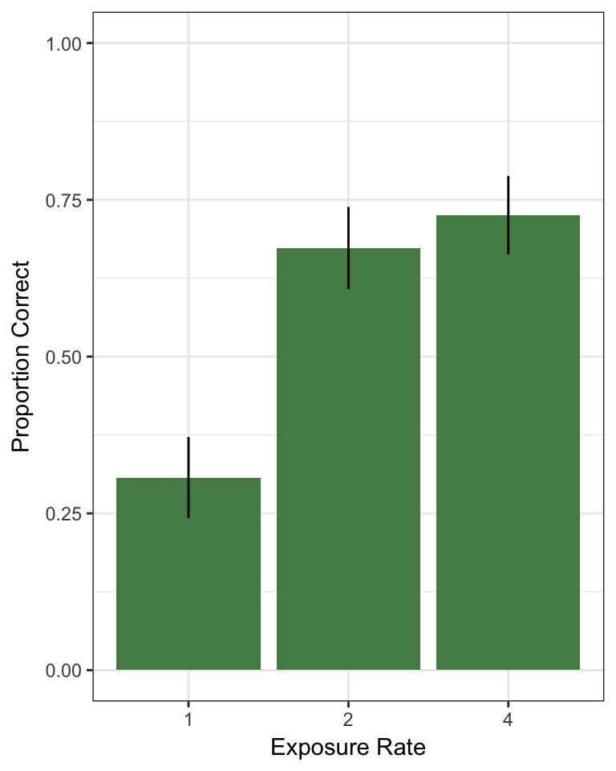

### Prediciting message strategy

In the plot below you can see some evidence of the two main effects that we expected. (1) Participants seem to be more likely to label an object if the label is a word they were exposed to more frequently. This is sensbile, because, as we showed above, knowledge scales with exposure as well. (2) Participants in the 100_30 condition, where sending a label is relatively less costly than the other condition, seem to produce more labels than participants in the 80_50 condition, where the relative costs make labeling less advantageous than the other condition.

We can build in a simple choice axiom to quantitately predict what the data should look like and compare these predictions against the empirical data above. The plot below shows those predictions for each of our conditions based on the assumption that one’s partner has perfect knowledge.

We can see that these predictions fit the data quite well. There is some evidence that people are underlabeling compared to the predicted rates, especially for the lower frequency words.

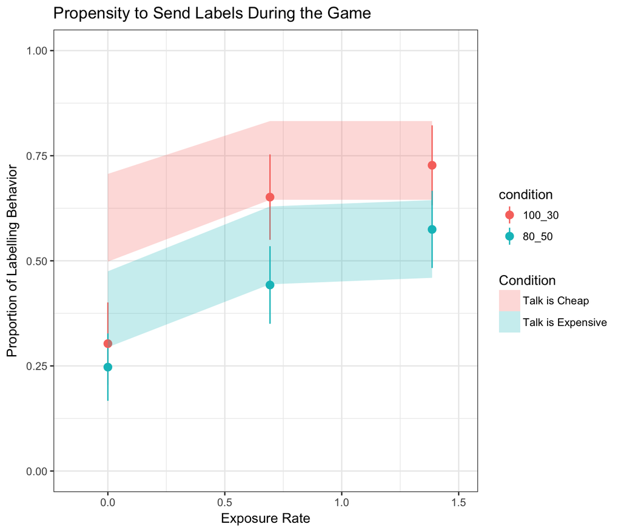

Another prediction would be that people assume their partner knows as much as they do. In this formulation, we use the same choice axiom as above but square the knowledge term (K) resulting in a more conservative estimate of what the partner is expected to know. This model seems to provide an even cleaner fit to the data, especially for the lower frequency words that the previous model didn’t match as well.

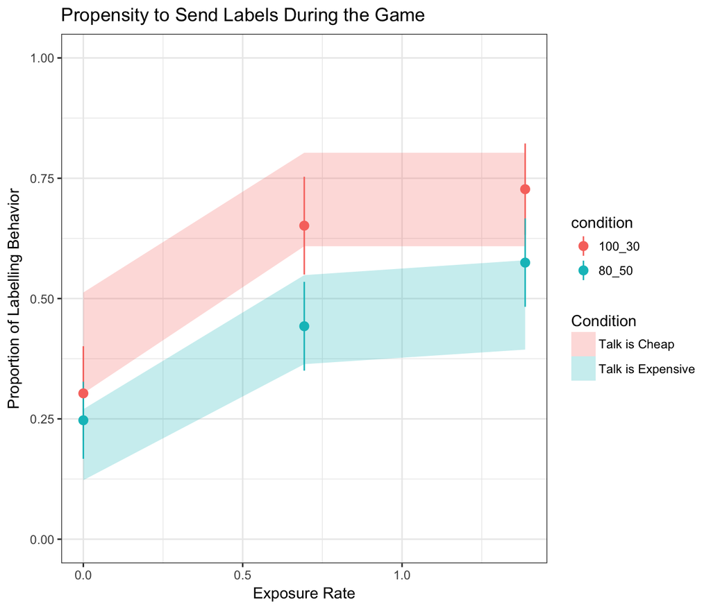

### Adapting On-line: First versus. Second Trial Behavior

We are also interested in how people adapt their decision to communicate based on the feedback they receive during the gaming. The plot below shows how often Ps label during second trials only, based on whether they correctly labeled the last appearance of that object.

People are clearly acting sensibly such that they are much less likely to produce a label after having been incorrect last time (red bars) than after correctly identifiying that object (blue bars). There is a good deal of noise here, likely because we have restricted to only second trial data where the first trial was a label. The limited available data means we cannot reliably identify whether a relationship exists with exposure rate.

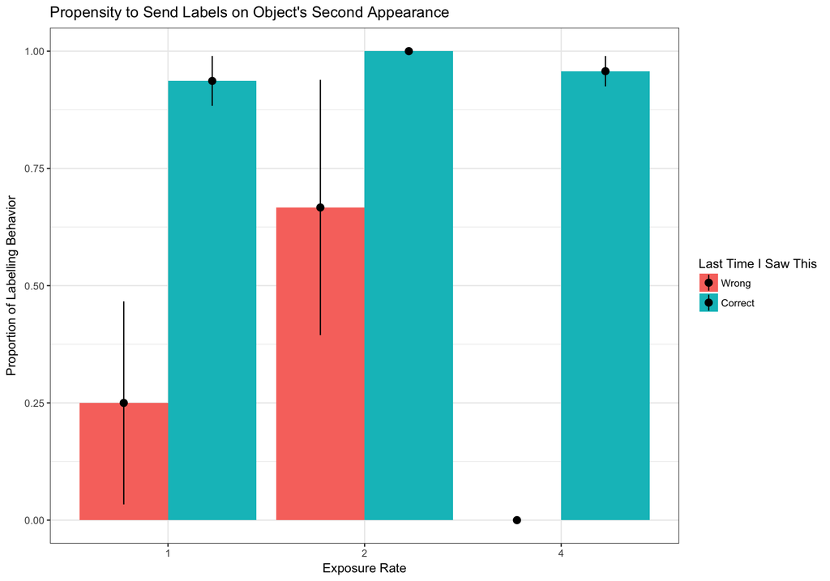

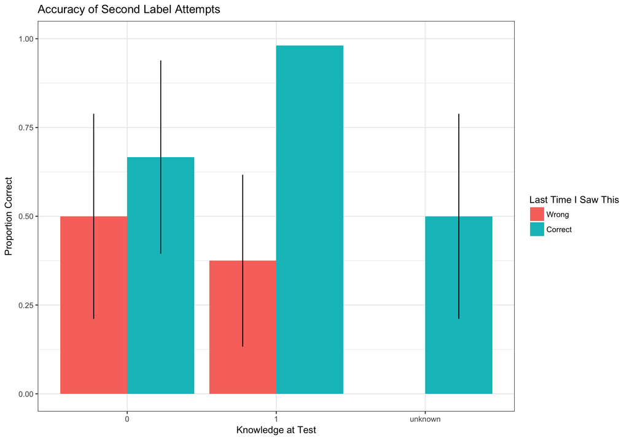

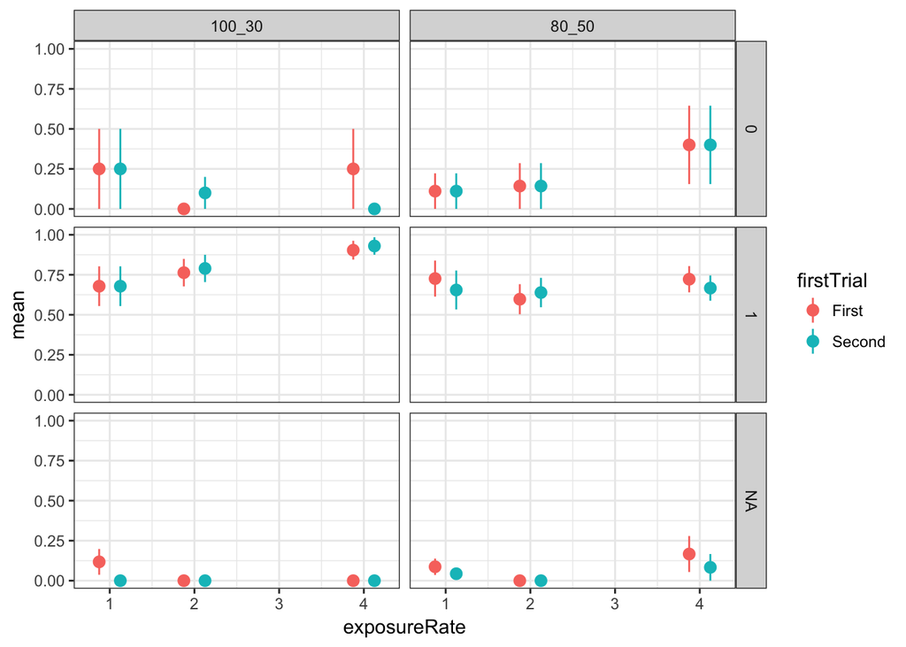

```r
# this one is just first vs. second, but without the nuance of what happend at first
# quartz(width = 10, height = 7)
ggplot(sender_game_data, aes(x = exposureRate, y = mean, color = firstTrial)) +
  facet_grid(known ~ condition) +
  geom_pointrange(aes(ymin = mean - sem, ymax = mean + sem),
                  position = position_dodge(.5)) +
  scale_y_continuous(limits = c(0,1))
```

## (old stuff)

Possible condition differences in pre-game knowledge?